# Pre-Data

Yusuke Fukasawa

2015年11月1日

ここでは実験を行う前に必要な各種数的処理を報告します。

# archiveの分布を調べる

```r
require(ggplot2)
ar<-read.csv("testdata_3.csv")
ar<-ar[,-1]
# archiveの統計量
summary(ar)
```

```
##     archive0         archive1         archive2         archive3
##  Min.   :243712   Min.   :239040   Min.   :203099   Min.   :230144
##  1st Qu.:303880   1st Qu.:265600   1st Qu.:262834   1st Qu.:300756
##  Median :335104   Median :292160   Median :274781   Median :315892
##  Mean   :330273   Mean   :298469   Mean   :277869   Mean   :319301
##  3rd Qu.:350336   3rd Qu.:332000   3rd Qu.:298551   3rd Qu.:341620
##  Max.   :396032   Max.   :387972   Max.   :365424   Max.   :390416
##     archive4         archive5         archive6         archive7
##  Min.   :240210   Min.   :249299   Min.   :239088   Min.   :251158
##  1st Qu.:271819   1st Qu.:288662   1st Qu.:291201   1st Qu.:282730
##  Median :299901   Median :314620   Median :313803   Median :310254
##  Mean   :297085   Mean   :324746   Mean   :326454   Mean   :311108
##  3rd Qu.:314182   3rd Qu.:363968   3rd Qu.:368828   3rd Qu.:330347
##  Max.   :357025   Max.   :430144   Max.   :416936   Max.   :375440
##     archive8         archive9        archive10        archive11
##  Min.   :220368   Min.   :266679   Min.   :199822   Min.   :232800
##  1st Qu.:268835   1st Qu.:300837   1st Qu.:285460   1st Qu.:276100
##  Median :298850   Median :313740   Median :306870   Median :291000
##  Mean   :297001   Mean   :325992   Mean   :310263   Mean   :299431
##  3rd Qu.:329094   3rd Qu.:345114   3rd Qu.:341140   3rd Qu.:320100
##  Max.   :350825   Max.   :407862   Max.   :380848   Max.   :363750
##    archive12        archive13        archive14        archive15
##  Min.   :222300   Min.   :242284   Min.   :237600   Min.   :175000
##  1st Qu.:297496   1st Qu.:285040   1st Qu.:290400   1st Qu.:250000
##  Median :315106   Median :334365   Median :303600   Median :275000
##  Mean   :310884   Mean   :322124   Mean   :303250   Mean   :272770
##  3rd Qu.:329429   3rd Qu.:356431   3rd Qu.:318412   3rd Qu.:298340
##  Max.   :372398   Max.   :402922   Max.   :343200   Max.   :352032
##    archive16        archive17        archive18        archive19
##  Min.   :190092   Min.   :216529   Min.   :249220   Min.   :230688
##  1st Qu.:285138   1st Qu.:268489   1st Qu.:303580   1st Qu.:254734
##  Median :309407   Median :292951   Median :322520   Median :274890
##  Mean   :309556   Mean   :288668   Mean   :323025   Mean   :279211
##  3rd Qu.:334347   3rd Qu.:305688   3rd Qu.:333938   3rd Qu.:301070
##  Max.   :383150   Max.   :339144   Max.   :425012   Max.   :346032
```

```r
# 徴税表を作成するためにヒストグラムが欲しかった
# とりあえず散布図を見てみる
ar.hist<-c(ar$archive0,ar$archive1,ar$archive2,ar$archive3,ar$archive4,ar$archive5,ar$archive6,ar$archive7,ar$archive8,ar$archive9,ar$archive10,ar$archive11,ar$archive12,ar$archive13,ar$archive14,ar$archive15,ar$archive16,ar$archive17,ar$archive18,ar$archive19)
summary(ar.hist)
```

```
##    Min. 1st Qu.  Median    Mean 3rd Qu.    Max.
##  175000  278700  303600  306400  332300  430100
```

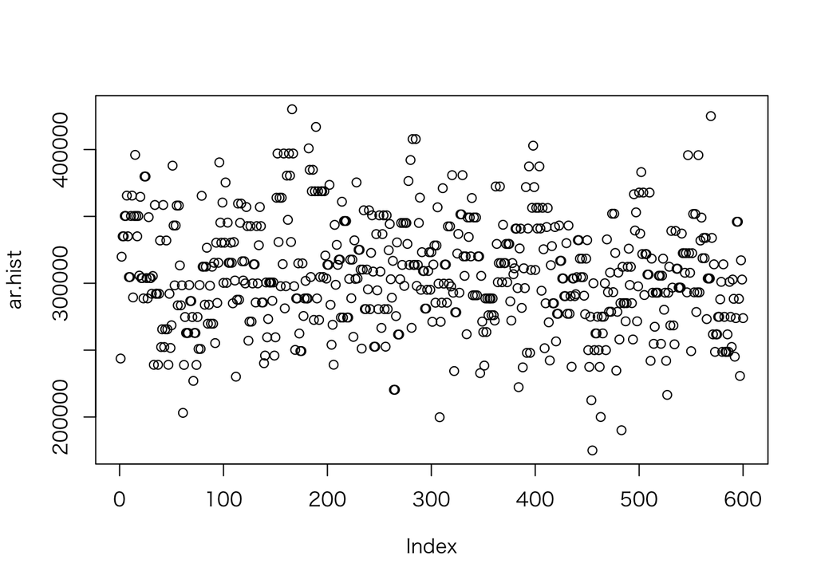

```r
plot(ar.hist)
```

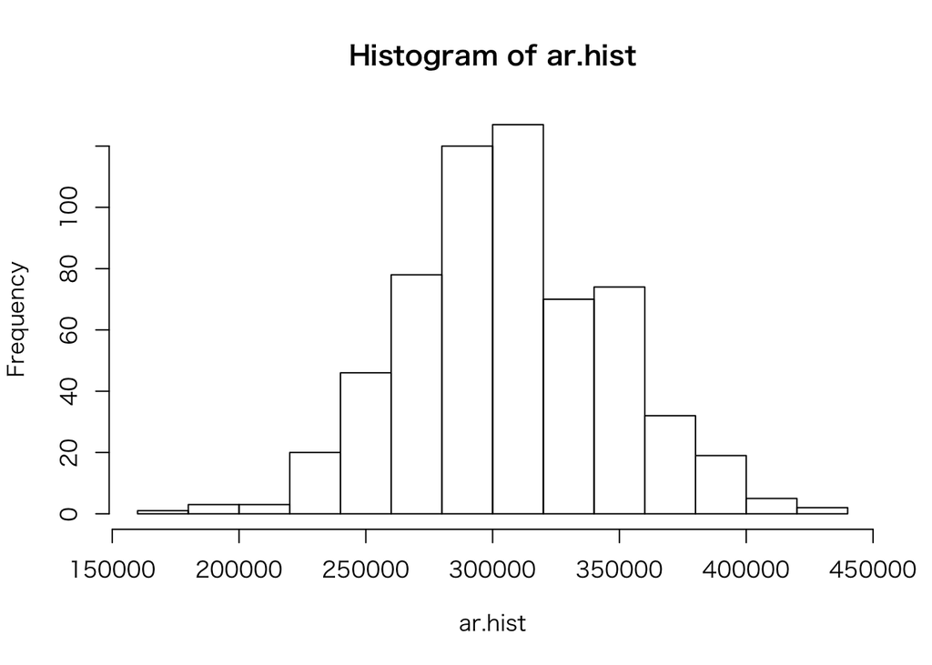

```r
# まんべんなく散らばっている模様。正規分布乱数で出しているのでそりゃそうかという感じですが。
# ヒストグラムを出す
hist(ar.hist)
```

月収25万から35万がボリュームゾーンのようですね 取り敢えずこの結果を受けて徴税表 (年ごとに徴税するので12倍)は暫定的に以下のようにしました 月収基準では200000,278700,303600,332300,400000でした。4分位点を参考にしつつ。

```r
tax.table<-c("2400000円以下","3344400円以下","3643200円以下","3987600円以下","4800000円以上")
tax.table<-data.frame(tax.table)
tax.table$rate<-c(0.05,0.15,0.25,0.35,0.45)
names(tax.table)<-c("Rule","Rate")
knitr::kable(tax.table)
```

| Rule | Rate |
| --- | --- |
| 2400000円以下 | 0.05 |
| 3344400円以下 | 0.15 |
| 3643200円以下 | 0.25 |
| 3987600円以下 | 0.35 |
| 4800000円以上 | 0.45 |

ちなみに現在の所得税徴収表を参考にしておりますので、参考資料をば

| 課税される所得金額 | 税率 | 控除額 |
| --- | --- | --- |
| 195万円以下 | 5% | 0円 |
| 195万円を超え、330万円以下 | 10% | 97,500円 |
| 330万円を超え、695万円以下 | 20% | 427,500円 |
| 695万円を超え、900万円以下 | 23% | 636,000円 |
| 900万円を超え、1,800万円以下 | 33% | 1,536,000円 |
| 1,800万円を超え、4.000万円以下 | 40% | 2,796,000円 |
| 4,000万円超 | 45% | 4,796,000円 |

# 効用関数を構成するパラメータのスケーリング

効用関数を定義するパラメータとして消費額、余暇時間、交通時間を用いるつもりですが、これらを並列して扱えるようにスケーリングします

```r
mm<-read.csv("testdata.csv")
mm<-mm[,c(-1,-2)]
# 概要
knitr::kable(mm)
```

| freetime | movetime | consump |
| --- | --- | --- |
| 878.60 | 2020.40 | 72883.50 |
| 1033.70 | 2185.30 | 73361.75 |
| 1032.25 | 2191.75 | 81883.20 |
| 1034.45 | 2196.55 | 81515.15 |
| 1065.50 | 2174.50 | 87253.25 |
| 895.25 | 2093.75 | 65137.00 |
| 909.95 | 2146.05 | 78061.85 |
| 911.80 | 2135.20 | 70716.40 |
| 923.05 | 2135.95 | 81522.20 |
| 933.70 | 2186.30 | 78978.05 |
| 1013.90 | 2156.10 | 77181.75 |
| 912.55 | 2173.45 | 81310.15 |
| 963.10 | 2143.90 | 72113.65 |
| 968.20 | 2160.80 | 83337.80 |
| 903.00 | 2128.00 | 75587.35 |
| 853.55 | 2163.45 | 73273.00 |
| 879.90 | 2062.10 | 64539.75 |
| 977.65 | 2173.35 | 79372.40 |
| 927.95 | 2139.05 | 75669.05 |
| 855.55 | 2150.45 | 75337.20 |
| 874.60 | 2133.40 | 75897.95 |
| 901.80 | 2067.20 | 80468.50 |
| 1013.80 | 2144.20 | 72989.10 |
| 860.05 | 2134.95 | 87741.05 |
| 921.75 | 2157.25 | 75058.40 |
| 1000.70 | 2141.30 | 85389.80 |
| 878.40 | 2072.60 | 77761.75 |
| 943.10 | 2160.90 | 73652.20 |
| 921.50 | 2169.50 | 91726.40 |
| 961.70 | 2178.30 | 89956.05 |

```r
# 平均など
summary(mm)
```

```
##     freetime         movetime       consump
##  Min.   : 853.5   Min.   :2020   Min.   :64540
##  1st Qu.: 896.9   1st Qu.:2135   1st Qu.:73434
##  Median : 922.4   Median :2148   Median :77472
##  Mean   : 938.4   Mean   :2143   Mean   :77989
##  3rd Qu.: 975.3   3rd Qu.:2172   3rd Qu.:81520
##  Max.   :1065.5   Max.   :2197   Max.   :91726
```

```r
# 標準偏差
sapply(mm,sd)
```

```
##   freetime   movetime    consump
##   60.05197   41.68926 6526.42411
```

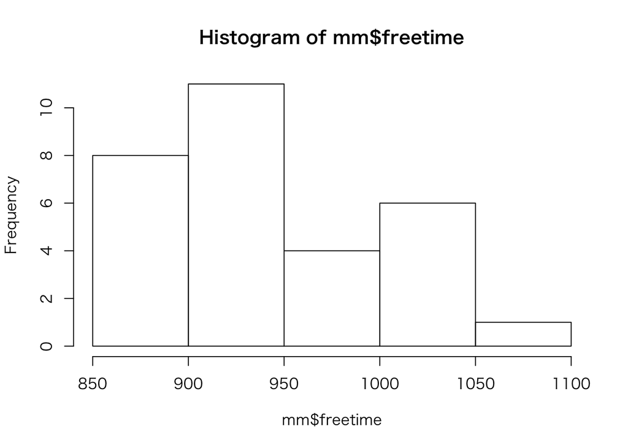

```r
# 各変数のヒストグラム
hist(mm$freetime)
```

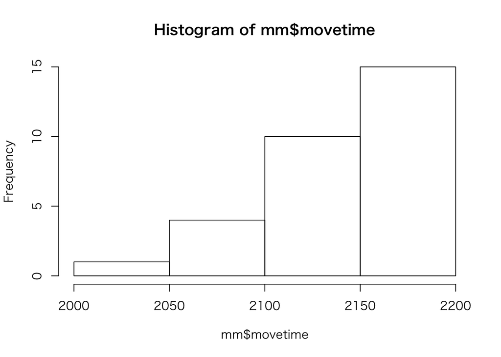

```r
hist(mm$movetime)
```

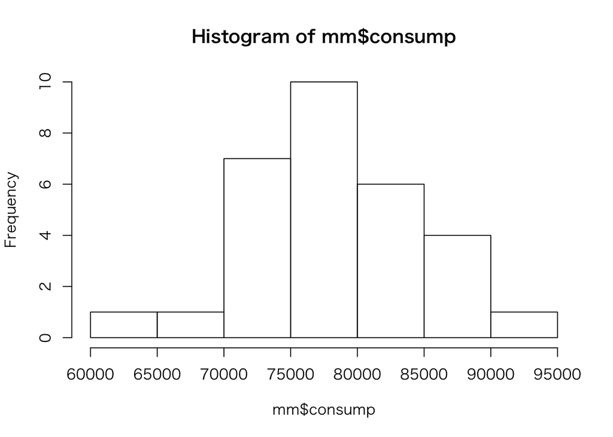

```r
hist(mm$consump)
```

これらの値を用いてそれぞれ標準化する式を組み立てると

となる。 10を足しているのは、このままだと負の値が出てしまって処理に不具合が出るので分散はそのままに平均だけ動かすという意図のもとです。この式を用いて改めて分布を見てみます。

```r
scaletable<-mm
scaletable$freetime<-((mm$freetime-938.4)/60.5)+10
scaletable$movetime<-((mm$movetime-2142.5)/41.7)+10
scaletable$consump<-((mm$consump-77989.19)/6526.4)+10
names(scaletable)<-c("freetime_std","movetime_std","consump_std")
# 概要
knitr::kable(scaletable)
```

| freetime_std | movetime_std | consump_std |
| --- | --- | --- |
| 9.011570 | 7.071942 | 9.217687 |
| 11.575207 | 11.026379 | 9.290966 |
| 11.551240 | 11.181055 | 10.596655 |
| 11.587603 | 11.296163 | 10.540261 |
| 12.100826 | 10.767386 | 11.419475 |
| 9.286777 | 8.830935 | 8.030738 |
| 9.529752 | 10.085132 | 10.011133 |
| 9.560331 | 9.824940 | 8.885635 |
| 9.746281 | 9.842926 | 10.541341 |
| 9.922314 | 11.050360 | 10.151517 |
| 11.247934 | 10.326139 | 9.876281 |
| 9.572727 | 10.742206 | 10.508850 |
| 10.408264 | 10.033573 | 9.099727 |
| 10.492562 | 10.438849 | 10.819534 |
| 9.414876 | 9.652278 | 9.631981 |
| 8.597521 | 10.502398 | 9.277367 |
| 9.033058 | 8.071942 | 7.939225 |
| 10.648760 | 10.739808 | 10.211941 |
| 9.827273 | 9.917266 | 9.644499 |
| 8.630579 | 10.190648 | 9.593652 |
| 8.945455 | 9.781775 | 9.679572 |
| 9.395041 | 8.194245 | 10.379889 |
| 11.246281 | 10.040767 | 9.233867 |
| 8.704959 | 9.818945 | 11.494217 |
| 9.724793 | 10.353717 | 9.550933 |
| 11.029752 | 9.971223 | 11.133950 |
| 9.008264 | 8.323741 | 9.965151 |
| 10.077686 | 10.441247 | 9.335470 |
| 9.720661 | 10.647482 | 12.104868 |
| 10.385124 | 10.858513 | 11.833608 |

```r
# 平均など
summary(scaletable)
```

```
##   freetime_std     movetime_std     consump_std
##  Min.   : 8.598   Min.   : 7.072   Min.   : 7.939
##  1st Qu.: 9.314   1st Qu.: 9.820   1st Qu.: 9.302
##  Median : 9.736   Median :10.138   Median : 9.921
##  Mean   : 9.999   Mean   :10.001   Mean   :10.000
##  3rd Qu.:10.610   3rd Qu.:10.717   3rd Qu.:10.541
##  Max.   :12.101   Max.   :11.296   Max.   :12.105
```

```r
# 標準偏差
sapply(scaletable,sd)
```

```
## freetime_std movetime_std  consump_std
##    0.9925946    0.9997424    1.0000037
```

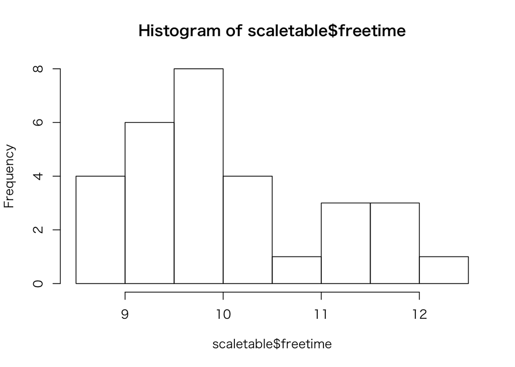

```r
# 各変数のヒストグラム
hist(scaletable$freetime)
```

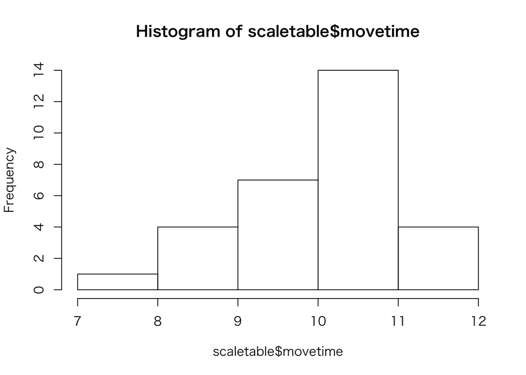

```r
hist(scaletable$movetime)
```

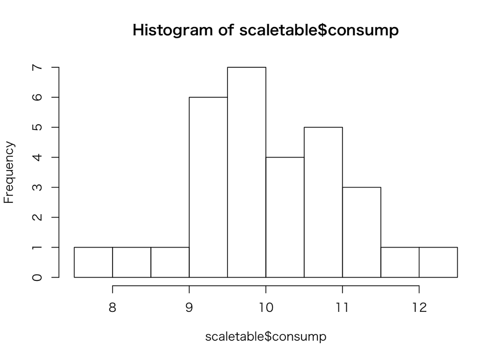

```r
hist(scaletable$consump)
```

これをしたからといって正規分布に近似させたいわけではなく、あくまでもスケーリングのためです。。。 効用の値も算出してみます

```r
scaletable$trial<-1:30
scaletable$utilize<-(scaletable$freetime)^0.33+(scaletable$movetime)^0.33-(scaletable$consump)^0.33
# 平均など
summary(scaletable$utilize)
```

```
##    Min. 1st Qu.  Median    Mean 3rd Qu.    Max.
##   1.892   2.078   2.137   2.136   2.221   2.365
```

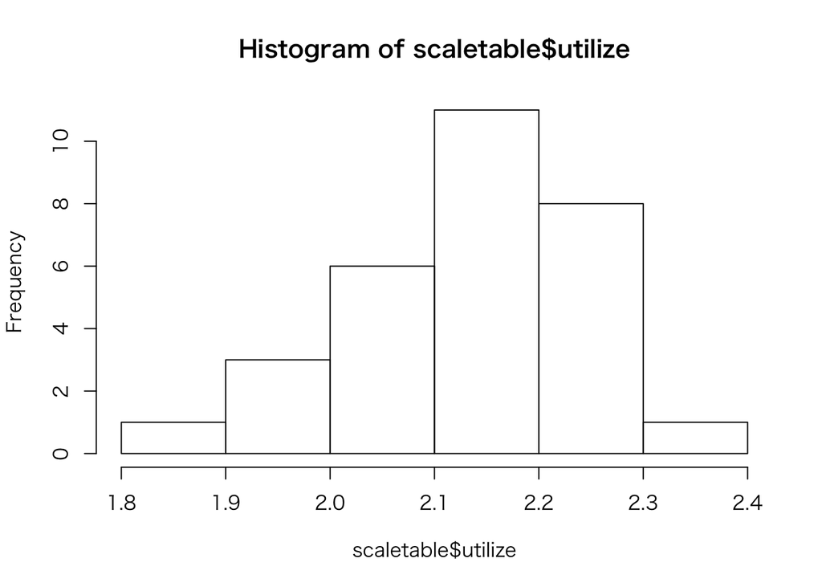

```r
# ヒストグラム
hist(scaletable$utilize)
```

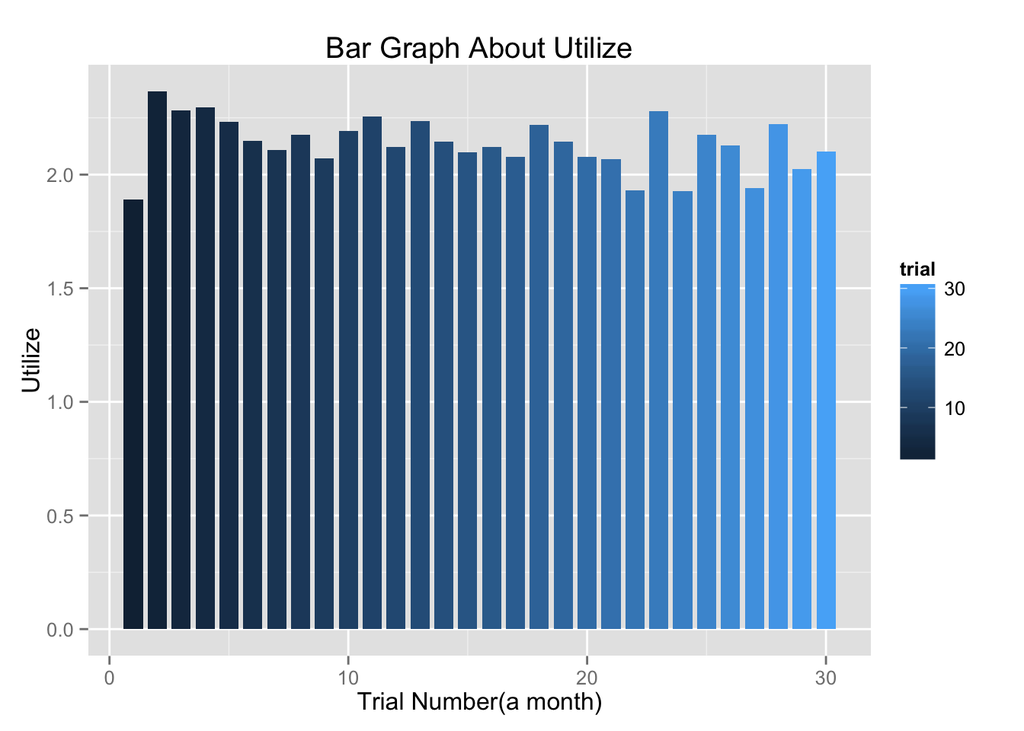

```r
# ggplot2で棒グラフにしてみる
g <- ggplot(
  scaletable,                    # ggplot 用データフレーム
  aes (                  # ggplot オプション設定
    x = trial,           # x 軸を df$group とする
    y = utilize,          # y 軸を df$length とする
    fill = trial         # df$group に従ってグループ分ける
  )
)
g <- g + geom_bar(                    # plotbarに当たる関数
  width = 0.8,                        # 棒の幅
  stat = "identity"
)
g <- g + xlab("Trial Number(a month)")            # x 軸名
g <- g + ylab("Utilize")       # y 軸名
g <- g + ggtitle("Bar Graph About Utilize")   # グラフ名

plot(g)
```

# 単年度処理、長年度処理の判断ポイント

微分して傾きが最大になるとかならないとかで決めます まず、確かめがてら効用関数を一階微分・二階微分してみます

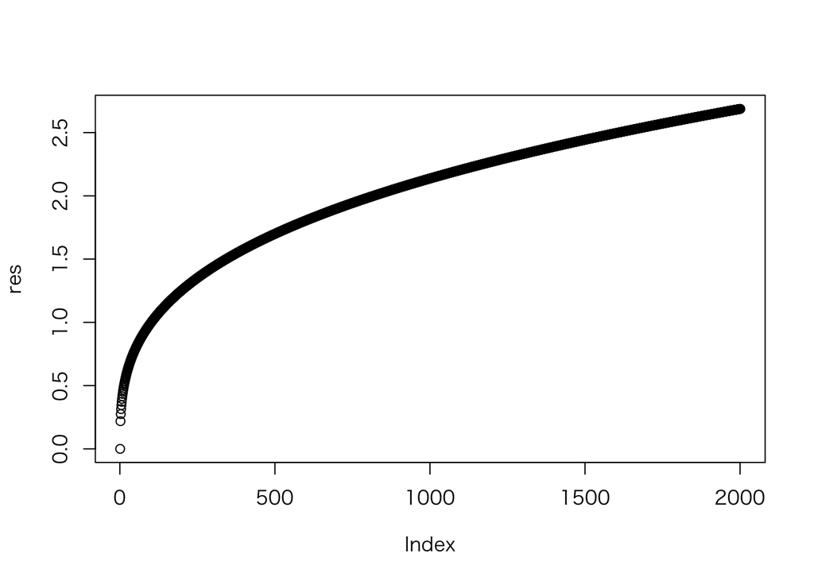

```r
u <- expression(x^0.33+y^0.33-z^0.33)
# 一階微分
uxyz<-deriv(u,c("x","y","z"),func=TRUE)
x<-seq(from=0,to=20,by=0.01)
y<-seq(from=0,to=20,by=0.01)
z<-seq(from=0,to=20,by=0.01)
res<-uxyz(x,y,z)
plot(res)
```

```r
# 二階微分したいところですが、やり方がわからないので一旦保留
```

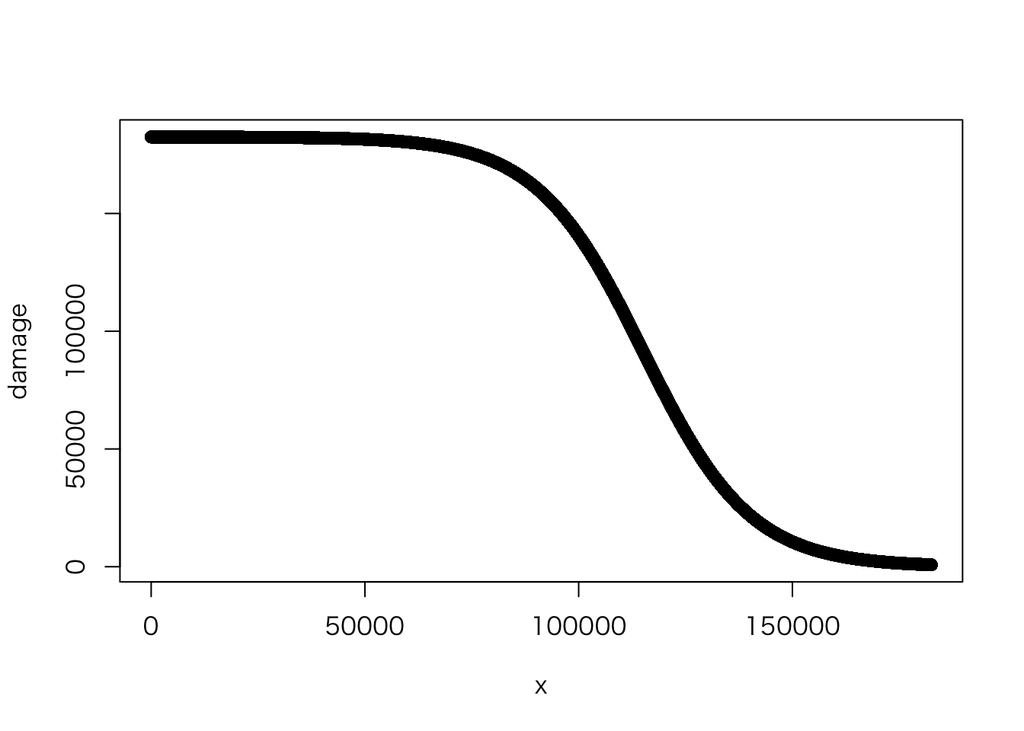

```r
res3<-c()
res3$x<-1:182500
res3$damage<-1
res3<-data.frame(res3)
res3$damage<-182500*(1-(1/(1+10000*exp((-0.008)*(res3$x/100)))))
plot(res3)
```

```r
# 一階微分します
d<-expression(182500*(1-(1/(1+10000*exp((-0.008)*(t/100))))))
dt<-deriv(d,"t",func = TRUE)
t<-seq(from=1,to=182500,by=1)
res4<-dt(t)
```